# YOLO vs Faster R-CNN Under Limited Compute

## Agenda

1. Problem framing and constraints
2. Data and evaluation protocol
3. Baseline ablations (10 epochs)
4. Hero extension (30 epochs total)
5. Key findings and takeaways

```python
from pathlib import Path
import json
import pandas as pd
import matplotlib.pyplot as plt
from PIL import Image
from IPython.display import display, Markdown

ROOT = Path.cwd()
RUNS = ROOT / 'runs'
QH = RUNS / 'qualitative_hero'

paths = {
    'summary_csv': RUNS / 'summary_results.csv',
    'baseline_plot': RUNS / 'comparison_plots.png',
    'hero_metrics_csv': QH / 'hero_test_eval_metrics.csv',
    'hero_deltas_csv': QH / 'hero_test_eval_deltas.csv',
    'hero_split_json': QH / 'hero_test_split_info.json',
    'hero_delta_plot': QH / 'hero_test_ap_deltas.png',
    'hero_ap_plot': QH / 'hero_test_before_after_ap.png',
    'hero_ap50_plot': QH / 'hero_test_before_after_ap50.png',
    'hero_ap75_plot': QH / 'hero_test_before_after_ap75.png',
    'yolo_results_plot': RUNS / 'detect' / 'runs' / 'yolo_resnet50_sgd_hero' / 'results.png',
}

print('Project root:', ROOT)
print('Artifact check:')
for k, p in paths.items():
    print(f'  {k}:', 'OK' if p.exists() else f'MISSING -> {p}')
```

```
Project root: c:\Users\Magz8\OneDrive\Documents\GitHub\COCO Object Detection
Artifact check:
  summary_csv: OK
  baseline_plot: OK
  hero_metrics_csv: OK
  hero_deltas_csv: OK
  hero_split_json: OK
  hero_delta_plot: OK
  hero_ap_plot: OK
  hero_ap50_plot: OK
  hero_ap75_plot: OK
  yolo_results_plot: OK
```

## Experiment Constraints

- Hardware: NVIDIA RTX 3050 Ti Laptop GPU (4GB VRAM)
- Data loader workers constrained to 0 for stability
- Fixed image size: 512
- Compared families: YOLO and Faster R-CNN
- Baseline schedule: 10 epochs
- Hero schedule: continued to 30 epochs total

```python
summary = pd.read_csv(paths['summary_csv'])
summary_ok = summary[summary['status'] == 'ok'].copy()
summary_view = summary_ok[[
    'family', 'backbone', 'optimizer', 'ap', 'ap50', 'ap75', 'train_seconds', 'phase'
]].sort_values(['family', 'backbone', 'optimizer']).reset_index(drop=True)

display(Markdown('### Baseline Results Table (10 Epochs)'))
display(summary_view.style.format({
    'ap': '{:.4f}',
    'ap50': '{:.4f}',
    'ap75': '{:.4f}',
    'train_seconds': '{:.2f}'
}))
```

Baseline Results Table (10 Epochs)

|  | family | backbone | optimizer | ap | ap50 | ap75 | train_seconds | phase |
| --- | --- | --- | --- | --- | --- | --- | --- | --- |
| 0 | fasterrcnn | resnet18 | sgd | 0.0391 | 0.0830 | 0.0312 | 1133.58 | sanity-fast |
| 1 | fasterrcnn | resnet50 | adam | 0.1084 | 0.2322 | 0.0762 | 1629.68 | sanity-fast |
| 2 | fasterrcnn | resnet50 | sgd | 0.1189 | 0.2531 | 0.0943 | 1538.13 | sanity-fast |
| 3 | yolo | resnet18 | sgd | 0.2807 | 0.4070 | 0.3004 | 803.29 | sanity-fast |
| 4 | yolo | resnet50 | adam | 0.0138 | 0.0264 | 0.0132 | 817.35 | sanity-fast |
| 5 | yolo | resnet50 | sgd | 0.3639 | 0.5122 | 0.3830 | 812.21 | sanity-fast |

Baseline Summary Figure

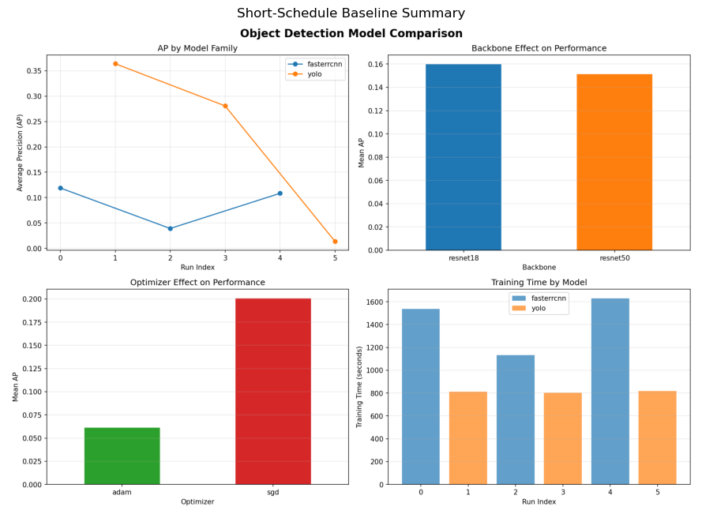

```python
display(Markdown('### Baseline Summary Figure'))
img = Image.open(paths['baseline_plot'])
plt.figure(figsize=(14, 8))
plt.imshow(img)
plt.axis('off')
plt.title('Short-Schedule Baseline Summary')
plt.show()
```

## Held-Out Non-Sampled Test Protocol

Test set design:

- Built from non-sampled training pool
- Seeded random sampling for reproducibility
- Same test images used for before-vs-after hero comparison

```python
with open(paths['hero_split_json'], 'r', encoding='utf-8') as f:
    split_info = json.load(f)

display(Markdown('### Held-Out Split Details'))
display(pd.DataFrame([split_info]))
```

Held-Out Split Details

|  | seed | requested_test_size | actual_test_size | total_train_images | sampled_train_images | non_sampled_pool |
| --- | --- | --- | --- | --- | --- | --- |
| 0 | 42 | 500 | 500 | 8000 | 2000 | 6000 |

```python
hero_metrics = pd.read_csv(paths['hero_metrics_csv'])
hero_deltas = pd.read_csv(paths['hero_deltas_csv'])

display(Markdown('### Hero Run: Before vs After (Held-Out Test)'))
display(hero_metrics.style.format({'ap': '{:.4f}', 'ap50': '{:.4f}', 'ap75': '{:.4f}'}))

display(Markdown('### Hero Run: Deltas (After - Before)'))
display(hero_deltas.style.format({'delta_ap': '{:+.4f}', 'delta_ap50': '{:+.4f}', 'delta_ap75': '{:+.4f}'}))
```

Hero Run: Before vs After (Held-Out Test)

|  | model | phase | ap | ap50 | ap75 |
| --- | --- | --- | --- | --- | --- |
| 0 | YOLO | before | 0.4607 | 0.6267 | 0.4963 |
| 1 | YOLO | after | 0.3634 | 0.5206 | 0.3894 |
| 2 | Faster R-CNN | before | 0.1106 | 0.2448 | 0.0798 |
| 3 | Faster R-CNN | after | 0.2270 | 0.4068 | 0.2345 |

Hero Run: Deltas (After - Before)

|  | model | delta_ap | delta_ap50 | delta_ap75 |
| --- | --- | --- | --- | --- |
| 0 | YOLO | -0.0974 | -0.1062 | -0.1070 |
| 1 | Faster R-CNN | +0.1164 | +0.1620 | +0.1548 |

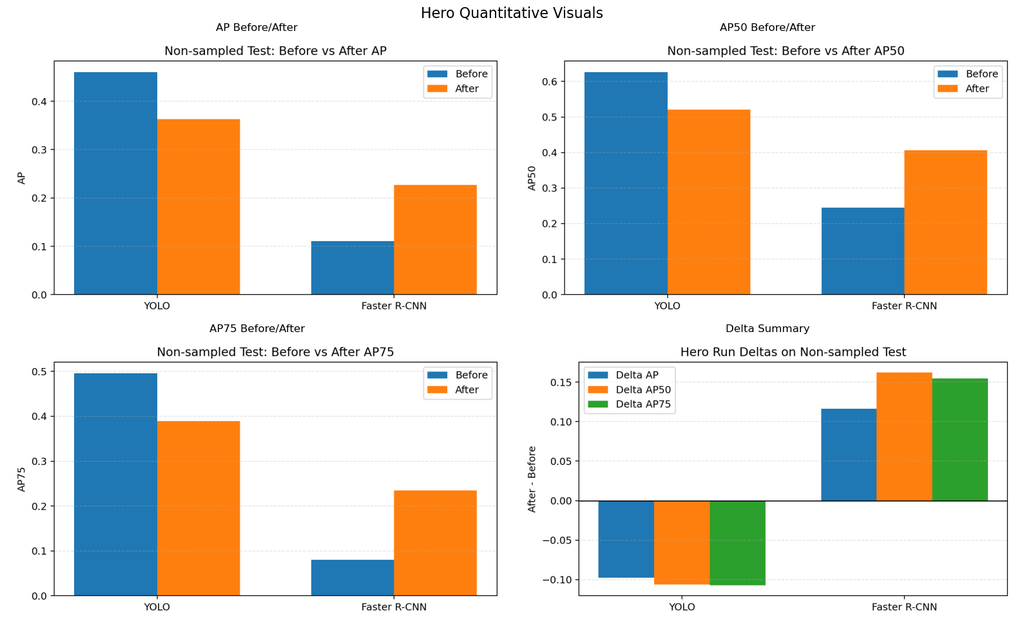

```python
fig, axes = plt.subplots(2, 2, figsize=(16, 10))
plots = [
    ('AP Before/After', paths['hero_ap_plot']),
    ('AP50 Before/After', paths['hero_ap50_plot']),
    ('AP75 Before/After', paths['hero_ap75_plot']),
    ('Delta Summary', paths['hero_delta_plot']),
]

for ax, (title, path) in zip(axes.flat, plots):
    ax.imshow(Image.open(path))
    ax.set_title(title)
    ax.axis('off')

plt.suptitle('Hero Quantitative Visuals', fontsize=16)
plt.tight_layout()
plt.show()
```

## Overfitting Evidence

The hero YOLO training curves are useful for diagnosis:

- Training losses continue improving
- Validation quality plateaus/oscillates
- Held-out test AP declines from before to after hero checkpoint

YOLO Hero Training Curves

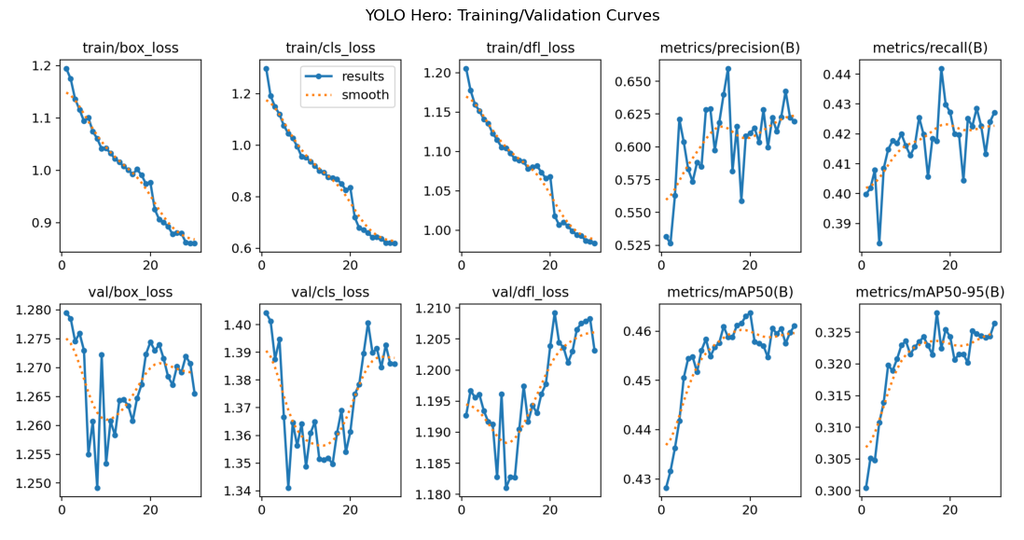

```python
display(Markdown('### YOLO Hero Training Curves'))
img = Image.open(paths['yolo_results_plot'])
plt.figure(figsize=(16, 7))
plt.imshow(img)
plt.axis('off')
plt.title('YOLO Hero: Training/Validation Curves')
plt.show()
```

Qualitative Before/After Panels

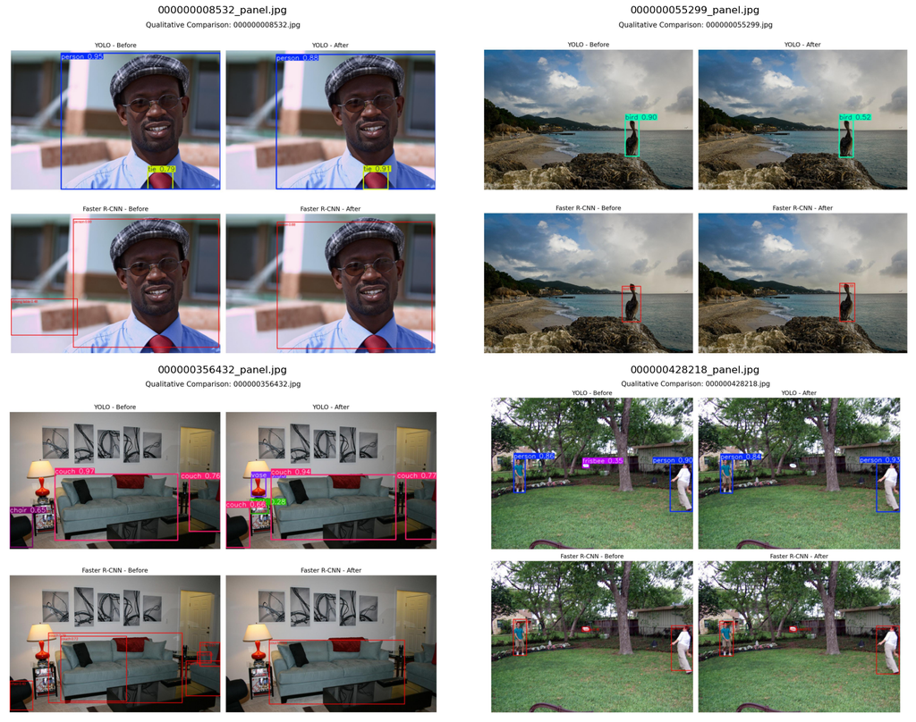

```python
panel_dir = QH / 'panels'
panel_files = sorted(panel_dir.glob('*.jpg'))

display(Markdown('### Qualitative Before/After Panels'))

if len(panel_files) == 0:
    print('No panel images found in', panel_dir)
else:
    cols = 2
    rows = (len(panel_files) + cols - 1) // cols
    fig, axes = plt.subplots(rows, cols, figsize=(16, 6 * rows))
    axes = axes.ravel() if hasattr(axes, 'ravel') else [axes]

    for i, p in enumerate(panel_files):
        axes[i].imshow(Image.open(p))
        axes[i].set_title(p.name)
        axes[i].axis('off')

    for j in range(i + 1, len(axes)):
        axes[j].axis('off')

    plt.tight_layout()
    plt.show()
```

## Final Takeaways

1. In short schedules (10 epochs), YOLO clearly outperforms Faster R-CNN in both AP and training efficiency.
2. Extended training helps Faster R-CNN substantially, showing it was under-trained in the short budget.
3. YOLO's hero checkpoint underperforms its earlier checkpoint on held-out non-sampled test data.
4. Ranking remains unchanged after hero: YOLO still leads, but the gap narrows.